# Análise descritiva dos Estudantes da UFCG

Leonardo Alves dos Santos

21-03-2016

```r
#Libraries
library(plyr)
library(dplyr)
library(ggplot2)
```

# Introdução

O conjunto de dados que será analisado possui 920.529 observações, e contém informações sobre os alunos matriculados, e as respectivas disciplinas, na UFCG (Universidade Federal de Campina Grande) nos periodo de 2002.1 até 2014.1. Cada linha no registro representa um aluno matriculado em uma disciplina em um dado periodo e o seu desempenho. A base de dados contém a informação de 32342 matriculas, o que não representa 32342 alunos distintos, pois um mesmo alunos pode possuir mais de uma matricula ao longo do tempo, ou por ter mudado de curso ou por ter limpado seu curriculo. Ao todo são registradas informações de 95 cursos e um total de 4217 disciplinas e 7 Campus.

```r
min_periodo = min(alunosUFCGAnon$Periodo)
max_periodo = max(alunosUFCGAnon$Periodo)
num_matriculas = length(unique(alunosUFCGAnon$Matricula))
num_cursos = length(unique(alunosUFCGAnon$Cod_Curso))
num_disci = length(unique(alunosUFCGAnon$Cod_Disciplina))
num_campus = length(unique(alunosUFCGAnon$Campus))
```

| Periodos | Número de Matriculas | Número de Cursos | Número de Disciplinas | Número de Campus |
| --- | --- | --- | --- | --- |
| 2002.1 - 2014.1 | 32342 | 95 | 4217 | 7 |

# Conhecendo Melhor os Dados

Abaixo podemos ver o conjunto completo de informações do data set.

```r
names(alunosUFCGAnon)
```

```
##  [1] "Matricula"        "Cod_Curso"        "Cod_Disciplina"
##  [4] "Cod_Evasao"       "Nome_Curso"       "Periodo"
##  [7] "Nome_Disciplina"  "Creditos"         "Departamento"
## [10] "Media_Disciplina" "Situacao"         "Centro"
## [13] "Campus"           "Creditos_Curso"   "Tipo"
## [16] "Periodo_Ingresso" "Periodo_Relativo"
```

Analisando os dados podemos ver a relação entre os alunos aprovados, reprovados e trancados. Como é de se esperar a principal parcelas dos dados relatam alunos aprovados nas disciplinas, 81.58%. 8.07% dos matriculados foram reprovados por nota, 7.51% foram reprovados por falta e 2.82 % representa os trancamentos.

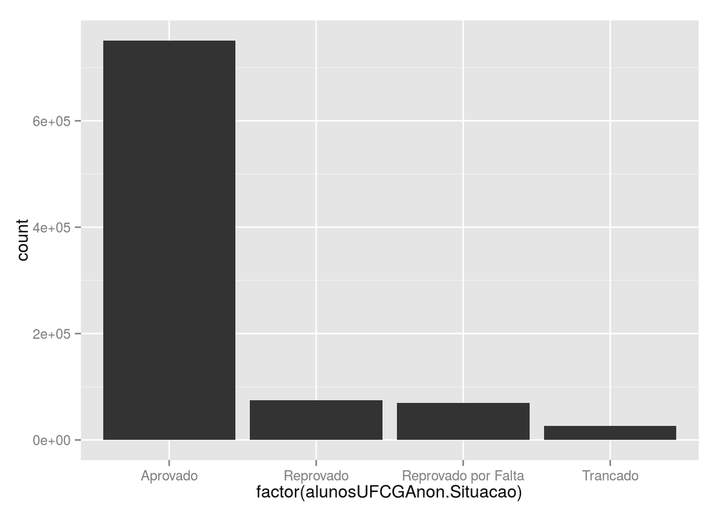

```r
sit_alunos = data.frame(alunosUFCGAnon$Situacao)
c <- ggplot(sit_alunos, aes(factor(alunosUFCGAnon.Situacao)))
c + geom_bar()
```

Outra forma de ver as informações acima é que a media das disciplinas, em geral estão acima de 5, justamente a nota de corte que define se um aluno foi o não aprovado em uma disciplina na instituição

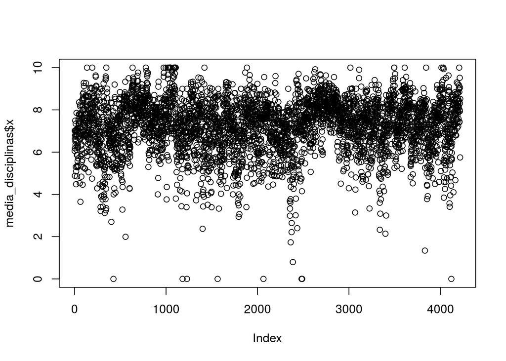

```r
media_disciplinas <- as.data.frame(aggregate(x=alunosUFCGAnon$Media_Disciplina,
                    by = list(alunosUFCGAnon$Cod_Disciplina), FUN=mean, na.rm=TRUE,                           simplify = TRUE, drop = TRUE))
plot(media_disciplinas$x)
```

Nas próximas seções tentaremos responder algumas perguntas sobre os dados.

# Ao Longo dos Anos, o desempenho dos alunos em uma disciplina melhorou ou se manteve?

Considerando como desempenho do aluno em uma disciplina a média dele na disciplina, minha hipótese é que os desempenhos tenham aumentado ao longo do tempo, devido ao fato do aluno ter novas fontes de consulta e de aprendizado. Devido ao fato de se ter muitas disciplinas, farei analise de um conjunto restrito delas. Selecionando, em especial, algumas disciplinas cursadas por alunos do curso de Ciência da Computação. Serão analisadas as seguites disciplinas:

- CALCULO DIFERENCIAL E INTEGRAL I
- CALCULO DIFERENCIAL E INTEGRAL II
- COMPILADORES
- ANÁLISE E TÉCNICA DE ALGORITMOS
- PROGRAMAÇÃO I

Para obter essa informação, os dados serão agrupados por periodo por disciplina e serão sumarizados pela média e mediana.

```r
grp = c("Periodo", "Nome_Disciplina")
dots =  lapply(grp, as.symbol)

dessempenho_disp_por_periodo = alunosUFCGAnon %>% group_by_(.dots=dots) %>%
    summarise(mean=mean(Media_Disciplina,na.rm=TRUE ),
    sd=sd(Media_Disciplina, na.rm=TRUE), median = median(Media_Disciplina, na.rm=TRUE))
```

Nos gráficos abaixo, cada dupla de barras representam dois periodos de um mesmo ano.

## CALCULO DIFERENCIAL E INTEGRAL I

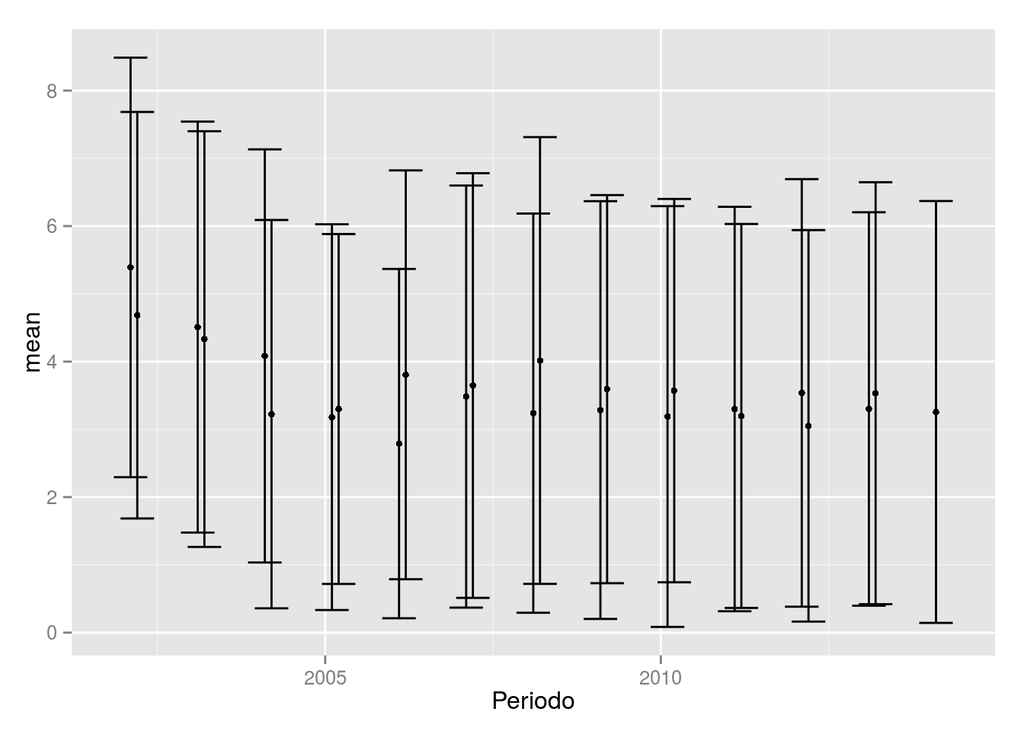

```r
desempenhoCAlC1 = dessempenho_disp_por_periodo[
        dessempenho_disp_por_periodo$Nome_Disciplina ==
        "CALCULO DIFERENCIAL E INTEGRAL I",]

ggplot(desempenhoCAlC1, aes(x=Periodo, y=mean)) +
  geom_point(stat = "identity", size = 1.5) +
  geom_errorbar(aes(ymin = mean - sd, ymax =  mean + sd), width = 0.5)
```

OBS.: O ponto representa a média dentro da variação. Variação = media +- Desvio Padrão

Quando se observa a Mediana, o periodo 2002.1 continua sendo um destaque em relação aos demais periodos. Uma observação que pode ser feita é que a uma grande variação nos dados. A média do Desvio Padrão é de 2.9798974, o que é relativamente alto.

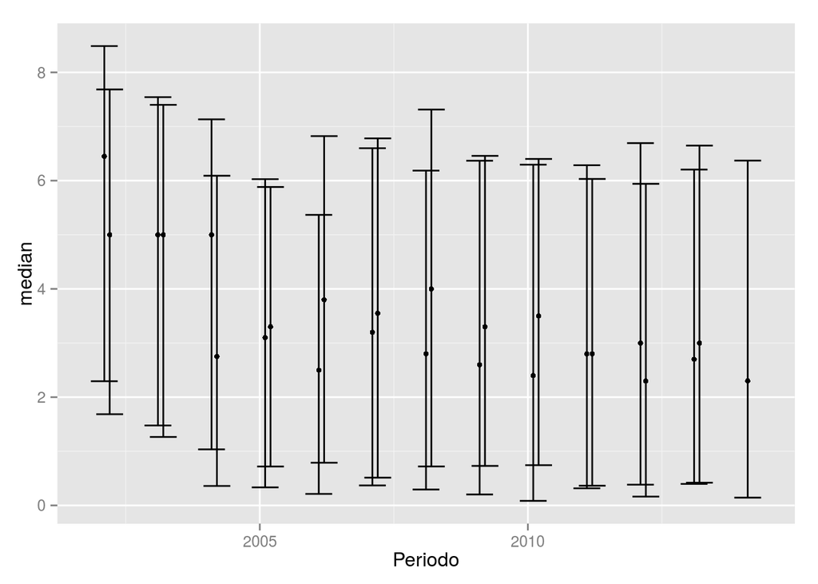

```r
ggplot(desempenhoCAlC1, aes(x=Periodo, y=median)) +
  geom_point(stat = "identity", size = 1.5) +
  geom_errorbar(aes(ymin = mean - sd, ymax =  mean + sd), width = 0.5)
```

OBS.: O ponto representa a Mediana dentro da variação. Variação = media +- Desvio Padrão

*Conclusão*

De forma superficial, visto que para fazer uma análise mais concreta seria preciso fazer testes estatisticos, pode-se dizer que ao contrário da hipotese inicial as notas dos alunos na disciplina de calculo diminuiram de 2002.1 a 2004.1 e depois disso se mantiveram muito próximas. Um pergunta que se pode fazer ao ver esse esse resultado é: Quais fatores devem estar influenciando esse resultado inferior?

## CALCULO DIFERENCIAL E INTEGRAL II

Ao contrário do que ocorre com calculo 1, não é possivel ver uma mudança visivel no comportamento das médias ao longo do tempo. Porém é possivel notar que em alguns periodos especificos se tem uma baixa na média, mas é um comportamento bastante pontual.

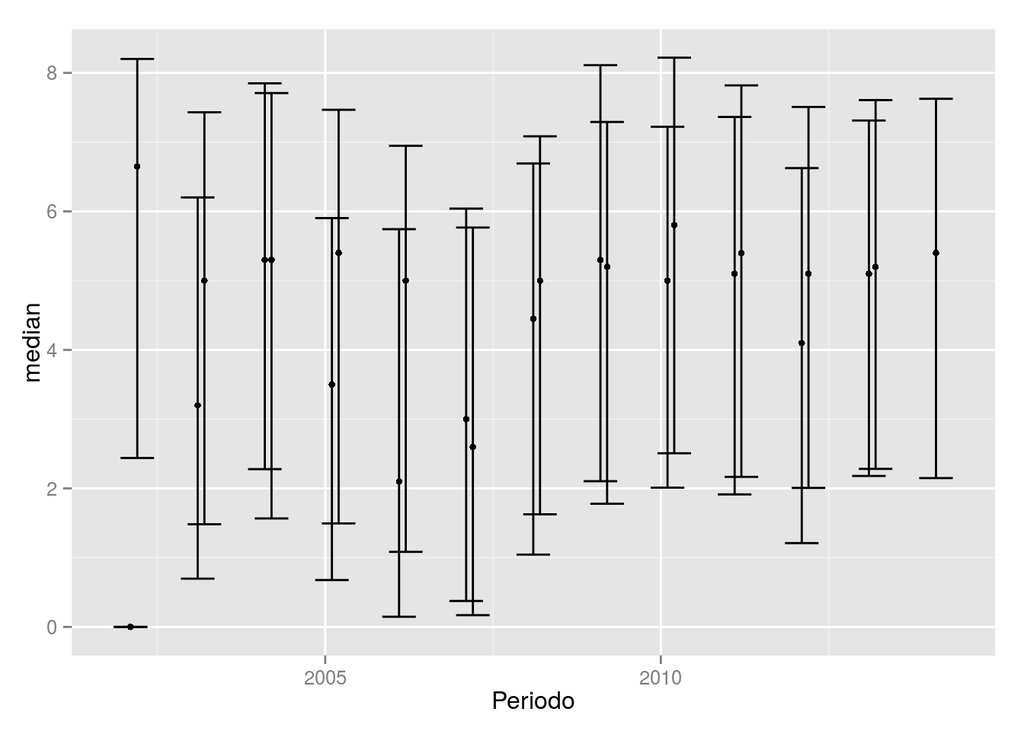

```r
desempenhoCAlC2 = dessempenho_disp_por_periodo[
    dessempenho_disp_por_periodo$Nome_Disciplina ==
      "CALCULO DIFERENCIAL E INTEGRAL II",]

ggplot(desempenhoCAlC2, aes(x=Periodo, y=median))  +
  geom_point(stat = "identity", size = 1.5) +
  geom_errorbar(aes(ymin = mean - sd, ymax =  mean + sd), width = 0.5)
```

Não existe uma diferença notavel quando se avalia a media e a médiana, embora em geral a mediana se apresente mais alta do que a média. Importante notar que os dados não trazem informções consistentes sobre o periodod de 2002.1, por isso a média zero, que não representa q todos os alunos tiraram 0 neste periodo, mas sim inconsistência dos dados.

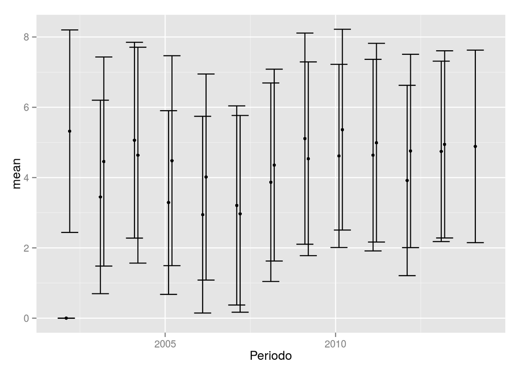

```r
ggplot(desempenhoCAlC2, aes(x=Periodo, y=mean))  +
  geom_point(stat = "identity", size = 1.5) +
  geom_errorbar(aes(ymin = mean - sd, ymax =  mean + sd), width = 0.5)
```

*Conclusão* Não houve uma mudança no desempenho dos alunos ao longo do tempo. Quanto a variação das notas, continuou muito parecida, apenas um pouco inferior, com a de Calculo I, em torno de 2.6872779.

## COMPILADORES

Assim como ocorre com Calculo II, não aparenta ter ocorrido uma melhora no desempenho dos alunos ao longo do tempo. Porém, ao contrário do que acontece com as disciplinas de calculo, o desvio padrão se apresenta menor.

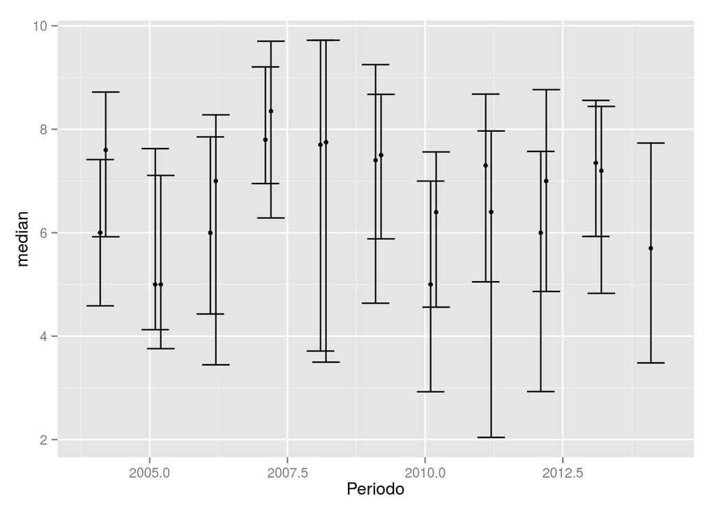

```r
desempenhoCOMPIL = dessempenho_disp_por_periodo[dessempenho_disp_por_periodo$Nome_Disciplina == "COMPILADORES",]
ggplot(desempenhoCOMPIL, aes(x=Periodo, y=median))  +
  geom_point(stat = "identity", size = 1.5) +
  geom_errorbar(aes(ymin = mean - sd, ymax =  mean + sd), width = 0.5)
```

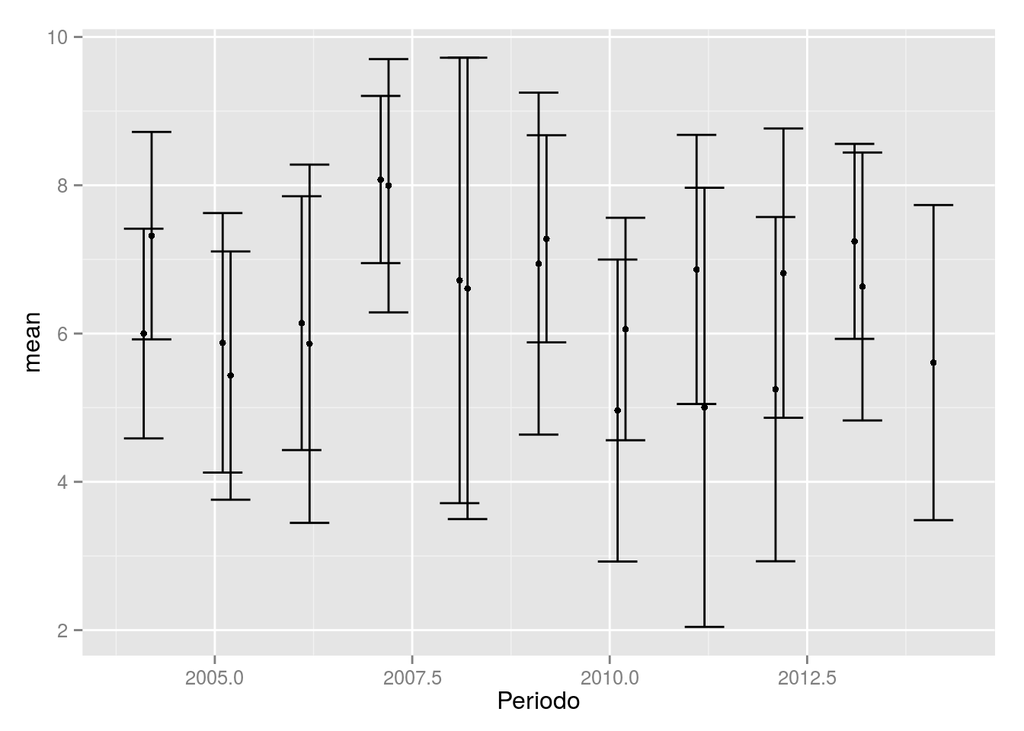

```r
ggplot(desempenhoCOMPIL, aes(x=Periodo, y=mean))  +
  geom_point(stat = "identity", size = 1.5) +
  geom_errorbar(aes(ymin = mean - sd, ymax =  mean + sd), width = 0.5)
```

A média do desvio padrão é de 1.9452027, quase 1 ponto a menos do que ocorre com calculo.

## ANÁLISE E TÉCNICA DE ALGORITMOS

Em ATAL, nota-se que ouve uma queda leve no desempenho, entre 2006.1 e 2008.2, porém nos anos seguintes o desempenho volta a subir.

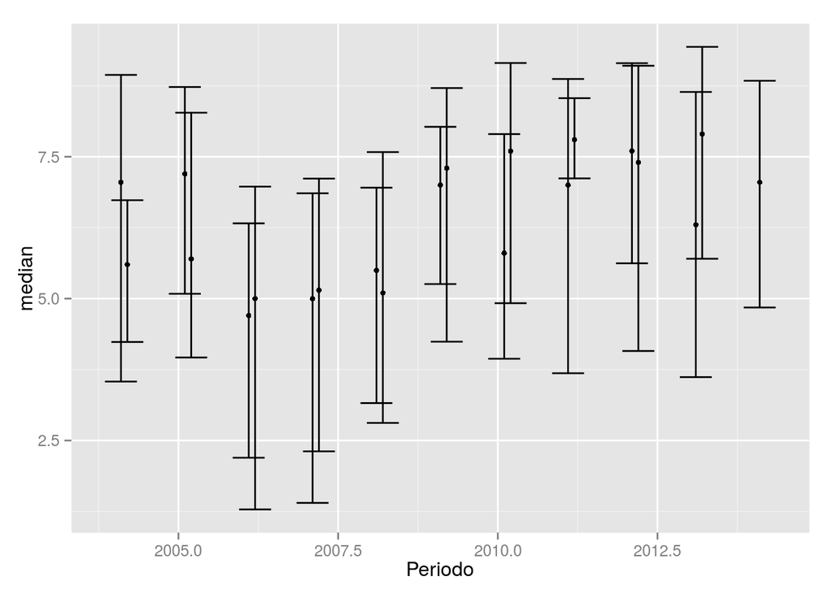

```r
desempenhoATAL = dessempenho_disp_por_periodo[
  dessempenho_disp_por_periodo$Nome_Disciplina == "ANÁLISE E TÉCNICA DE ALGORITMOS",]

ggplot(desempenhoATAL, aes(x=Periodo, y=median)) +
  geom_point(stat = "identity", size = 1.5) +
  geom_errorbar(aes(ymin = mean - sd, ymax =  mean + sd), width = 0.5)
```

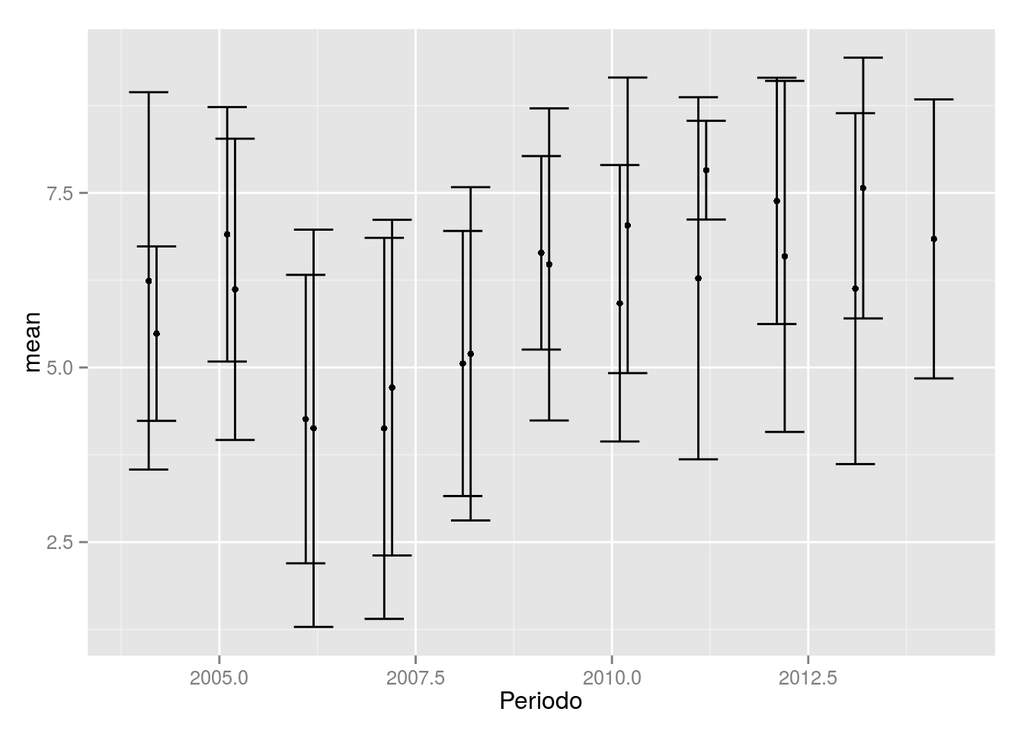

```r
ggplot(desempenhoATAL, aes(x=Periodo, y=mean))  +
  geom_point(stat = "identity", size = 1.5) +
  geom_errorbar(aes(ymin = mean - sd, ymax =  mean + sd), width = 0.5)
```

A média do desvio padrão é de 2.0913228, um pouco menor do que os Calculos e pouco maior que Compiladores.

## PROGRAMAÇÃO I

A disciplina de Programação I também é ofertada no primeiro periodo. Em geral o desempenho nesta disciplina é melhor do que em calculo I, no entanto, não houve melhoramento no desempenho, nem tão pouco houve uma piora ao longo do tempo.

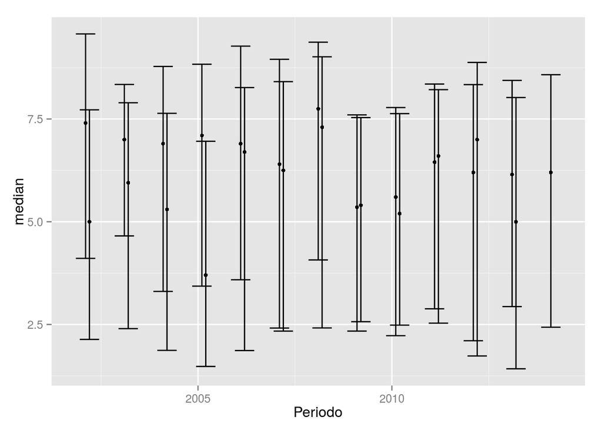

```r
desempenhoPROGI = dessempenho_disp_por_periodo[
  dessempenho_disp_por_periodo$Nome_Disciplina == "PROGRAMAÇÃO I",]

ggplot(desempenhoPROGI, aes(x=Periodo, y=median)) +
  geom_point(stat = "identity", size = 1.5) +
  geom_errorbar(aes(ymin = mean - sd, ymax =  mean + sd), width = 0.5)
```

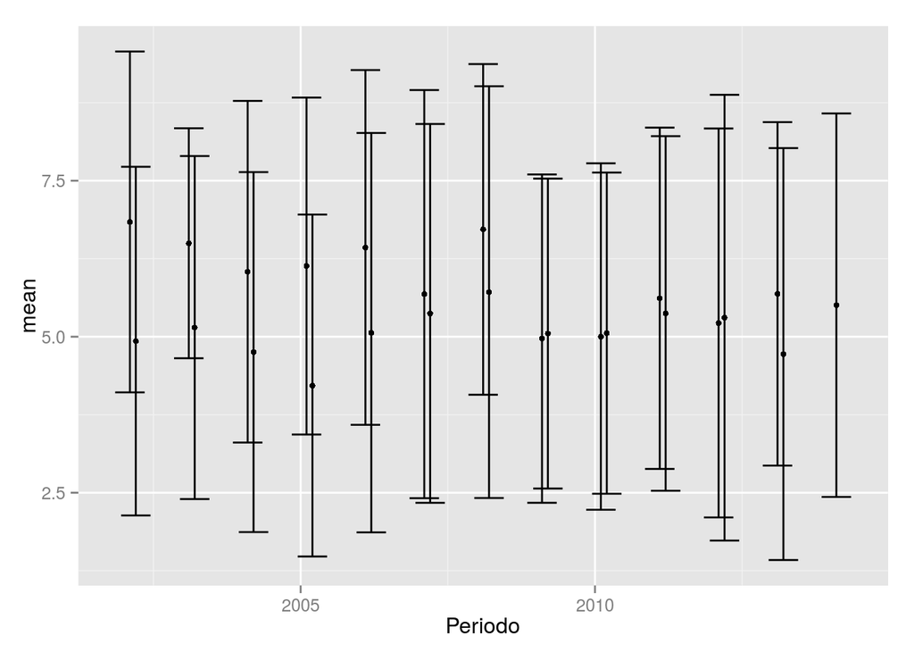

```r
ggplot(desempenhoPROGI, aes(x=Periodo, y=mean))  +
  geom_point(stat = "identity", size = 1.5) +
  geom_errorbar(aes(ymin = mean - sd, ymax =  mean + sd), width = 0.5)
```

O desvio padrão, assim como nos calculos, é alto: 2.8531521.

# Conclusão

Ao menos nas disciplinas escolhidas para análise, a hipotese inicial não paracer ser válida. Em Calculo I, por exemplo, ele se mostra o contrario: O desempenho dos alunos caiu ao longo do tempo. Exceto em ATAL, que mostrou um leve aumento no desempenho. Compiladores e Atal apresentaram uma variação menor no desempenho, em relação as demais analisada, como essas duas disciplinas são mais ao final do curso, pode-se perguntar se disciplinas iniciais apresentam maior variação do que disciplinas mais próximas ao fim do curso?